### Notes on this example report for the JCS

This is an example of a stats report generated mostly with randomly data. The graphs and analysis here presented a merelly examples coming from our limited minds, but the possibilities here are pretty much endless for the MoT and others to generate narratives based on true stats.

# REGIMENTAL RAID Data report - 505th Ressugence regiment

This report comprises Information gatehred from the deployments undertaken by the helldivers of the 505th Ressurgence regiment. The stats team thanks the collaboarion of hosts on supplying the screenshots data, and we also would like to acknowledge the time invested by the memebers of the stats team on gatehrting, cleaning and curating this data. This information is gathered from the final mission screenshots as well as information provided by the fireteam hosts.

The raid was undertaken in Vernen Wells, before 0:00 hr deployment time, this was the state of the planet

[figure not shown]

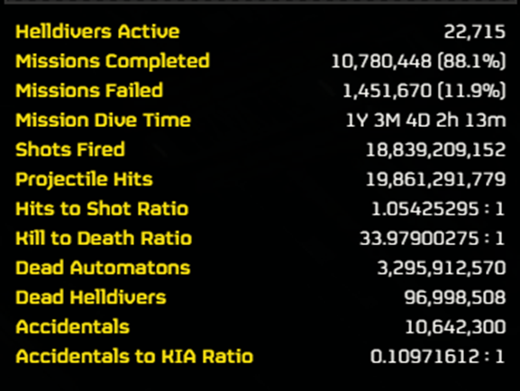

after the last raid deployment was finished, the state of the planet was as follows

[figure not shown]

[figure not shown]

```
A total of 55 deployments were undertaken, a total of 165 missions, 1.0 percent of the missions
```

```
The raid had a 100.0 percent success ratio, while overall the helldivers in Vernen wells had  97.0 percent success
```

## Deployment graphs

Here we present the stats regarding the operations undertaken in this regimental raid

```
A total of 55 deployments were undertaken by our helldivers. Bellow you will find the distribution of missions per difficullty and respective stats
```

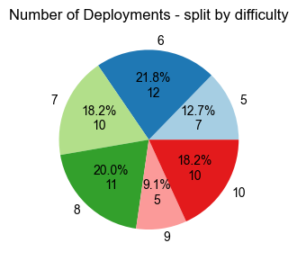

```
A total of 155552 enemies were killed, an average of 2828.0 per deployment
```

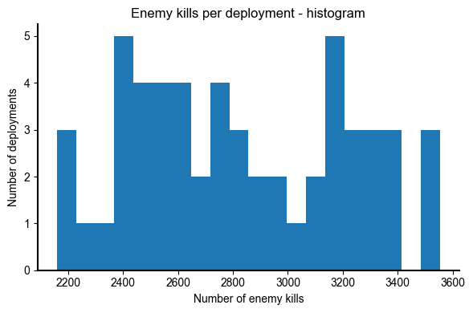

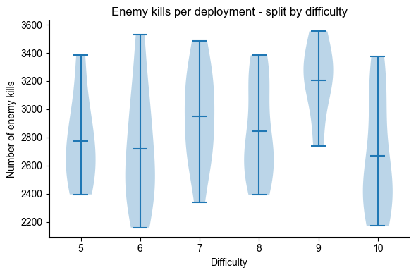

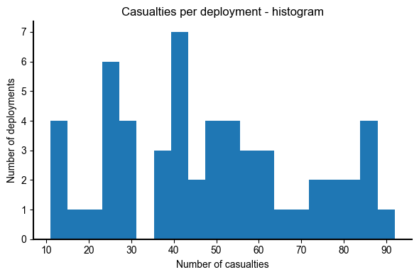

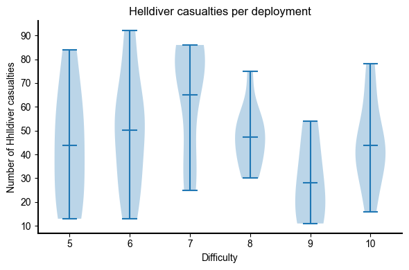

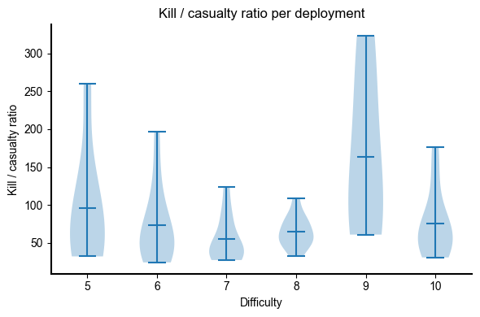

[figure not shown]

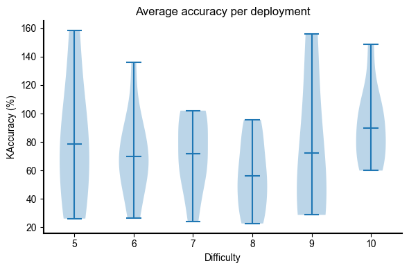

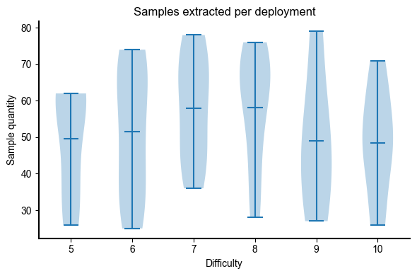

## Best performing fireteams

The 505th data departament would like to congratulate the helldivers that achieved the highest performace in this raid

```
The fireteam with the highest number of kills was Sirio_Pengus_Sloth_Oracle, with 3554 enemies downed
```

```
The fireteam with the lowest number of casualties was Sirio_Pengus_Sloth_Oracle, with 11 helldivers lost
```